# LTD Survey

Sophia Frantz

10/7/2019

To most efficiently conduct the survey of commuting distance for Eugene and Springfield residents, we should survey 150 people. We will get diminishing returns as the accuracy will only improve slightly beyond 150 people. Additionally, surveying 150 people will give us more than enough power to detect whether there is a true difference in mean distance traveled between Eugene and Springfield.

To determine this, I tested the accuracy in finding the true distance traveled from samples of distances for a simulated dataset with increasing sample size. I had to make reasonable assumptions about the population of Eugene and Springfield in order to create this dataset

First, I guessed the mean distance traveled in order to conduct simulations: The location with the highest number of workers from Eugene and Springfield will be downtown Eugene and the University. I chose the Eugene Public Library as a representative coordinate for “downtown and University”. I looked at the most populated neighborhoods in each cardinal direction of downtown using Census data. I excluded the West University neighborhood, assuming this neighborhood is mainly comprised of students who are not full-time employees. The neighborhoods are ~ 4 miles, 5 miles, 3 miles, 6 miles away from the library. The most populated neighborhoods in Springfield are ~ 6 miles, ~ 10 miles from Downtown Eugene. The overall mean of these distances is 5.7 (~6 miles). Next, I assumed that most people live within 6 miles of work and the number of people who live farther or shorter than that distance rapidly decreases. This description can be represented by an exponential distribution.

This means that to conduct the simulations that allowed me to determine the optimum sample size, I assumed that if we were able to sample every single person in Eugene and Springfield, the mean distance traveled would be 6 miles. If we pretend this is the real mean and we pretend that the distribution of distance traveled is exponential, then even if these assumptions are not precisely true but close enough, then we can use these assumptions to help us determine the sample size needed for our survey to get as close to the true mean as possible while sampling as few people as possible, which will save LTD money.

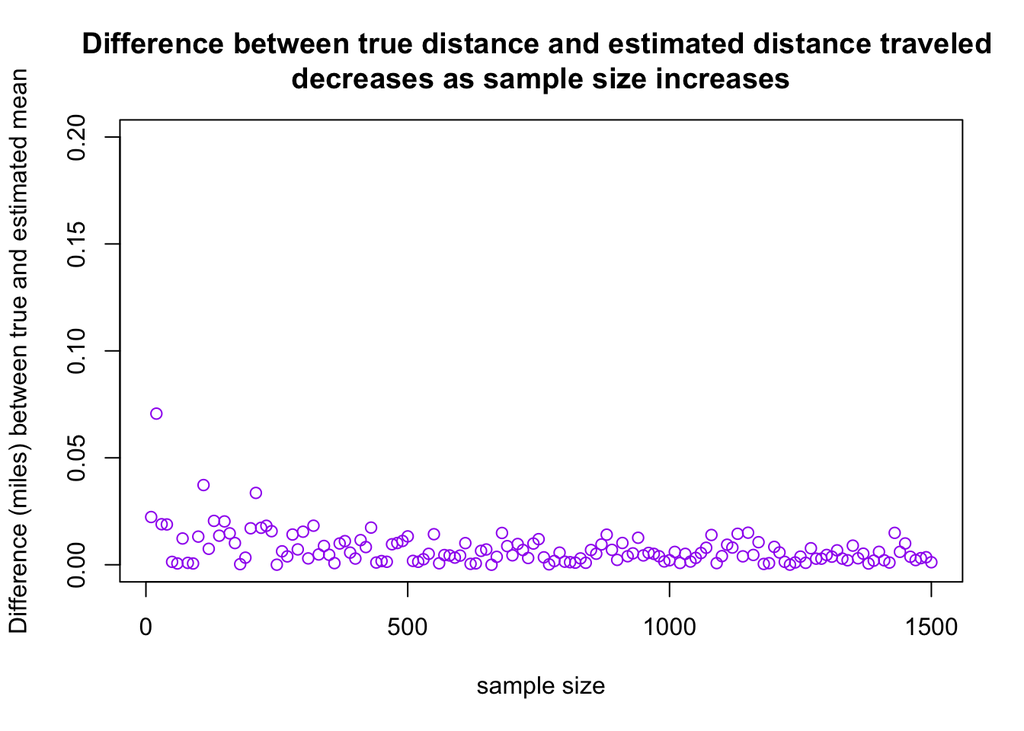

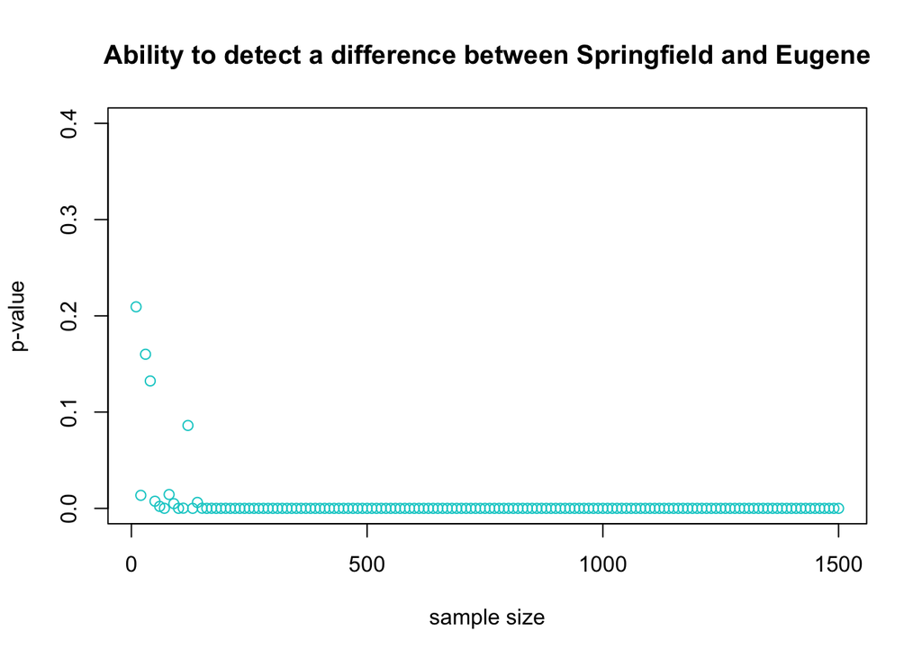